# _NOTEBOOK

```python
import pandas as pd
import numpy as np
```

```python
from google.colab import files
uploaded = files.upload()
```

Upload widget is only available when the cell has been executed in the current browser session. Please rerun this cell to enable.

```
Saving ncr_ride_bookings.csv to ncr_ride_bookings.csv
```

```python
df = pd.read_csv("ncr_ride_bookings.csv")
df.head(20)
```

|  | Date | Time | Booking ID | Booking Status | Customer ID | Vehicle Type | Pickup Location | Drop Location | Avg VTAT | Avg CTAT | ... | Reason for cancelling by Customer | Cancelled Rides by Driver | Driver Cancellation Reason | Incomplete Rides | Incomplete Rides Reason | Booking Value | Ride Distance | Driver Ratings | Customer Rating | Payment Method |
| --- | --- | --- | --- | --- | --- | --- | --- | --- | --- | --- | --- | --- | --- | --- | --- | --- | --- | --- | --- | --- | --- |
| 0 | 2024-03-23 | 12:29:38 | "CNR5884300" | No Driver Found | "CID1982111" | eBike | Palam Vihar | Jhilmil | NaN | NaN | ... | NaN | NaN | NaN | NaN | NaN | NaN | NaN | NaN | NaN | NaN |
| 1 | 2024-11-29 | 18:01:39 | "CNR1326809" | Incomplete | "CID4604802" | Go Sedan | Shastri Nagar | Gurgaon Sector 56 | 4.9 | 14.0 | ... | NaN | NaN | NaN | 1.0 | Vehicle Breakdown | 237.0 | 5.73 | NaN | NaN | UPI |
| 2 | 2024-08-23 | 08:56:10 | "CNR8494506" | Completed | "CID9202816" | Auto | Khandsa | Malviya Nagar | 13.4 | 25.8 | ... | NaN | NaN | NaN | NaN | NaN | 627.0 | 13.58 | 4.9 | 4.9 | Debit Card |
| 3 | 2024-10-21 | 17:17:25 | "CNR8906825" | Completed | "CID2610914" | Premier Sedan | Central Secretariat | Inderlok | 13.1 | 28.5 | ... | NaN | NaN | NaN | NaN | NaN | 416.0 | 34.02 | 4.6 | 5.0 | UPI |
| 4 | 2024-09-16 | 22:08:00 | "CNR1950162" | Completed | "CID9933542" | Bike | Ghitorni Village | Khan Market | 5.3 | 19.6 | ... | NaN | NaN | NaN | NaN | NaN | 737.0 | 48.21 | 4.1 | 4.3 | UPI |
| 5 | 2024-02-06 | 09:44:56 | "CNR4096693" | Completed | "CID4670564" | Auto | AIIMS | Narsinghpur | 5.1 | 18.1 | ... | NaN | NaN | NaN | NaN | NaN | 316.0 | 4.85 | 4.1 | 4.6 | UPI |
| 6 | 2024-06-17 | 15:45:58 | "CNR2002539" | Completed | "CID6800553" | Go Mini | Vaishali | Punjabi Bagh | 7.1 | 20.4 | ... | NaN | NaN | NaN | NaN | NaN | 640.0 | 41.24 | 4.0 | 4.1 | UPI |
| 7 | 2024-03-19 | 17:37:37 | "CNR6568000" | Completed | "CID8610436" | Auto | Mayur Vihar | Cyber Hub | 12.1 | 16.5 | ... | NaN | NaN | NaN | NaN | NaN | 136.0 | 6.56 | 4.4 | 4.2 | UPI |
| 8 | 2024-09-14 | 12:49:09 | "CNR4510807" | No Driver Found | "CID7873618" | Go Sedan | Noida Sector 62 | Noida Sector 18 | NaN | NaN | ... | NaN | NaN | NaN | NaN | NaN | NaN | NaN | NaN | NaN | NaN |
| 9 | 2024-12-16 | 19:06:48 | "CNR7721892" | Incomplete | "CID5214275" | Auto | Rohini | Adarsh Nagar | 6.1 | 26.0 | ... | NaN | NaN | NaN | 1.0 | Other Issue | 135.0 | 10.36 | NaN | NaN | Cash |
| 10 | 2024-06-14 | 16:24:12 | "CNR9070334" | Completed | "CID6680340" | Auto | Udyog Bhawan | Dwarka Sector 21 | 7.7 | 18.9 | ... | NaN | NaN | NaN | NaN | NaN | 181.0 | 19.84 | 4.2 | 4.9 | Cash |
| 11 | 2024-09-18 | 08:09:38 | "CNR9551927" | No Driver Found | "CID7568143" | Auto | Vidhan Sabha | AIIMS | NaN | NaN | ... | NaN | NaN | NaN | NaN | NaN | NaN | NaN | NaN | NaN | NaN |
| 12 | 2024-06-25 | 22:44:15 | "CNR4386945" | Cancelled by Driver | "CID5543520" | eBike | Patel Chowk | Kherki Daula Toll | 4.6 | NaN | ... | NaN | 1.0 | Personal & Car related issues | NaN | NaN | NaN | NaN | NaN | NaN | NaN |
| 13 | 2024-09-11 | 19:29:39 | "CNR2987763" | Completed | "CID2669710" | Go Mini | Malviya Nagar | Ghitorni Village | 12.2 | 28.2 | ... | NaN | NaN | NaN | NaN | NaN | 394.0 | 21.44 | 4.1 | 4.7 | UPI |
| 14 | 2024-10-18 | 18:28:53 | "CNR8962232" | Completed | "CID1789354" | Go Mini | Madipur | GTB Nagar | 14.0 | 30.9 | ... | NaN | NaN | NaN | NaN | NaN | 836.0 | 39.55 | 4.7 | 4.4 | UPI |
| 15 | 2024-06-07 | 15:05:35 | "CNR2390352" | Completed | "CID5432215" | Auto | Jama Masjid | Khan Market | 8.5 | 36.9 | ... | NaN | NaN | NaN | NaN | NaN | 410.0 | 34.76 | 4.0 | 4.9 | Uber Wallet |
| 16 | 2024-07-01 | 10:51:16 | "CNR3221338" | Completed | "CID2581698" | Premier Sedan | IGI Airport | Madipur | 5.6 | 27.5 | ... | NaN | NaN | NaN | NaN | NaN | 401.0 | 21.97 | 4.9 | 4.3 | UPI |
| 17 | 2024-12-15 | 15:08:25 | "CNR6739317" | Cancelled by Driver | "CID8682675" | Go Sedan | Vinobapuri | GTB Nagar | 6.0 | NaN | ... | NaN | 1.0 | Customer related issue | NaN | NaN | NaN | NaN | NaN | NaN | NaN |
| 18 | 2024-11-24 | 09:07:10 | "CNR6126048" | Cancelled by Customer | "CID1060329" | eBike | Kashmere Gate | Anand Vihar | 12.4 | NaN | ... | Driver is not moving towards pickup location | NaN | NaN | NaN | NaN | NaN | NaN | NaN | NaN | NaN |
| 19 | 2024-05-24 | 19:53:57 | "CNR9465840" | Cancelled by Driver | "CID9046501" | eBike | Pitampura | Rajiv Nagar | 10.3 | NaN | ... | NaN | 1.0 | Customer related issue | NaN | NaN | NaN | NaN | NaN | NaN | NaN |

20 rows × 21 columns

Explore Data Analysis

```python
df.columns
```

```
Index(['Date', 'Time', 'Booking ID', 'Booking Status', 'Customer ID',
       'Vehicle Type', 'Pickup Location', 'Drop Location', 'Avg VTAT',
       'Avg CTAT', 'Cancelled Rides by Customer',
       'Reason for cancelling by Customer', 'Cancelled Rides by Driver',
       'Driver Cancellation Reason', 'Incomplete Rides',
       'Incomplete Rides Reason', 'Booking Value', 'Ride Distance',
       'Driver Ratings', 'Customer Rating', 'Payment Method'],
      dtype='object')
```

```python
df.info()
```

```
<class 'pandas.core.frame.DataFrame'>
RangeIndex: 150000 entries, 0 to 149999
Data columns (total 21 columns):
 #   Column                             Non-Null Count   Dtype
---  ------                             --------------   -----
 0   Date                               150000 non-null  object
 1   Time                               150000 non-null  object
 2   Booking ID                         150000 non-null  object
 3   Booking Status                     150000 non-null  object
 4   Customer ID                        150000 non-null  object
 5   Vehicle Type                       150000 non-null  object
 6   Pickup Location                    150000 non-null  object
 7   Drop Location                      150000 non-null  object
 8   Avg VTAT                           139500 non-null  float64
 9   Avg CTAT                           102000 non-null  float64
 10  Cancelled Rides by Customer        10500 non-null   float64
 11  Reason for cancelling by Customer  10500 non-null   object
 12  Cancelled Rides by Driver          27000 non-null   float64
 13  Driver Cancellation Reason         27000 non-null   object
 14  Incomplete Rides                   9000 non-null    float64
 15  Incomplete Rides Reason            9000 non-null    object
 16  Booking Value                      102000 non-null  float64
 17  Ride Distance                      102000 non-null  float64
 18  Driver Ratings                     93000 non-null   float64
 19  Customer Rating                    93000 non-null   float64
 20  Payment Method                     102000 non-null  object
dtypes: float64(9), object(12)
memory usage: 24.0+ MB
```

```python
df.isna().sum()
```

|  | 0 |
| --- | --- |
| Date | 0 |
| Time | 0 |
| Booking ID | 0 |
| Booking Status | 0 |
| Customer ID | 0 |
| Vehicle Type | 0 |
| Pickup Location | 0 |
| Drop Location | 0 |
| Avg VTAT | 10500 |
| Avg CTAT | 48000 |
| Cancelled Rides by Customer | 139500 |
| Reason for cancelling by Customer | 139500 |
| Cancelled Rides by Driver | 123000 |
| Driver Cancellation Reason | 123000 |
| Incomplete Rides | 141000 |
| Incomplete Rides Reason | 141000 |
| Booking Value | 48000 |
| Ride Distance | 48000 |
| Driver Ratings | 57000 |
| Customer Rating | 57000 |
| Payment Method | 48000 |

**dtype:** int64

```python
#Threshold to drop
threshold = 0.8
df = df.loc[:, df.isnull().mean() < threshold]

df.info()
```

```
<class 'pandas.core.frame.DataFrame'>
RangeIndex: 150000 entries, 0 to 149999
Data columns (total 15 columns):
 #   Column           Non-Null Count   Dtype
---  ------           --------------   -----
 0   Date             150000 non-null  object
 1   Time             150000 non-null  object
 2   Booking ID       150000 non-null  object
 3   Booking Status   150000 non-null  object
 4   Customer ID      150000 non-null  object
 5   Vehicle Type     150000 non-null  object
 6   Pickup Location  150000 non-null  object
 7   Drop Location    150000 non-null  object
 8   Avg VTAT         139500 non-null  float64
 9   Avg CTAT         102000 non-null  float64
 10  Booking Value    102000 non-null  float64
 11  Ride Distance    102000 non-null  float64
 12  Driver Ratings   93000 non-null   float64
 13  Customer Rating  93000 non-null   float64
 14  Payment Method   102000 non-null  object
dtypes: float64(6), object(9)
memory usage: 17.2+ MB
```

```python
#dtypes conversion
#Date and Time
df['Date'] = pd.to_datetime(df['Date'])
df['Time'] = pd.to_datetime(df['Time'])

#BookingID and CustomerID
df['Booking ID'] = df['Booking ID'].astype(str)
df['Customer ID'] = df['Customer ID'].astype(str)


#categorical columns
cats_columns = ["Booking Status", "Vehicle Type", "Pickup Location","Drop Location","Payment Method"]

df[cats_columns] = df[cats_columns].astype("category")
df.info()
```

```
<class 'pandas.core.frame.DataFrame'>
RangeIndex: 150000 entries, 0 to 149999
Data columns (total 15 columns):
 #   Column           Non-Null Count   Dtype
---  ------           --------------   -----
 0   Date             150000 non-null  datetime64[ns]
 1   Time             150000 non-null  datetime64[ns]
 2   Booking ID       150000 non-null  object
 3   Booking Status   150000 non-null  category
 4   Customer ID      150000 non-null  object
 5   Vehicle Type     150000 non-null  category
 6   Pickup Location  150000 non-null  category
 7   Drop Location    150000 non-null  category
 8   Avg VTAT         139500 non-null  float64
 9   Avg CTAT         102000 non-null  float64
 10  Booking Value    102000 non-null  float64
 11  Ride Distance    102000 non-null  float64
 12  Driver Ratings   93000 non-null   float64
 13  Customer Rating  93000 non-null   float64
 14  Payment Method   102000 non-null  category
dtypes: category(5), datetime64[ns](2), float64(6), object(2)
memory usage: 12.5+ MB
```

```python
#drop "" in values
df["Booking ID"] = df["Booking ID"].str.replace('"', '', regex=False)
df["Customer ID"] = df["Customer ID"].str.replace('"', '', regex=False)
```

```python
print(df["Booking Status"].value_counts())
print(df[["Vehicle Type", "Avg VTAT", "Avg CTAT"]].isna().sum())
```

```
Booking Status
Completed                93000
Cancelled by Driver      27000
Cancelled by Customer    10500
No Driver Found          10500
Incomplete                9000
Name: count, dtype: int64
Vehicle Type        0
Avg VTAT        10500
Avg CTAT        48000
dtype: int64
```

```python
#fillna()
df["Avg VTAT"] = df["Avg VTAT"].fillna(df["Avg VTAT"].median())
df["Avg CTAT"] = df["Avg CTAT"].fillna(df["Avg CTAT"].median())
```

```python
#Find correlation
corr = df.corr(numeric_only=True)
corr
```

|  | Avg VTAT | Avg CTAT | Booking Value | Ride Distance | Driver Ratings | Customer Rating |
| --- | --- | --- | --- | --- | --- | --- |
| Avg VTAT | 1.000000 | 0.050914 | 0.002259 | 0.063005 | -0.005439 | -0.003945 |
| Avg CTAT | 0.050914 | 1.000000 | 0.000216 | 0.101503 | 0.000807 | 0.001000 |
| Booking Value | 0.002259 | 0.000216 | 1.000000 | 0.005174 | -0.000249 | -0.000287 |
| Ride Distance | 0.063005 | 0.101503 | 0.005174 | 1.000000 | -0.001875 | 0.004514 |
| Driver Ratings | -0.005439 | 0.000807 | -0.000249 | -0.001875 | 1.000000 | -0.001010 |
| Customer Rating | -0.003945 | 0.001000 | -0.000287 | 0.004514 | -0.001010 | 1.000000 |

```python
#Convert df["Booking Status"]
df["Booking Status"] = df["Booking Status"].apply(lambda x: 1 if x=="Completed" else 0)
print(df["Booking Status"].value_counts())
```

```
Booking Status
1    93000
0    57000
Name: count, dtype: int64
```

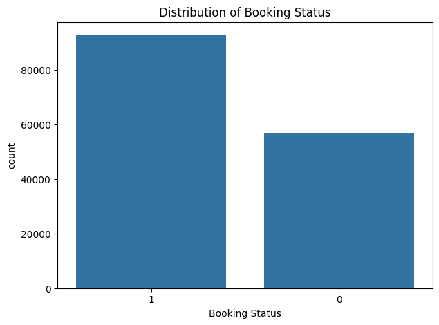

```python
import seaborn as sns
import matplotlib.pyplot as plt

plt.figure(figsize=(7,5))
sns.countplot(x="Booking Status", data=df, order=df["Booking Status"].value_counts().index)
plt.title("Distribution of Booking Status")
plt.show()
```

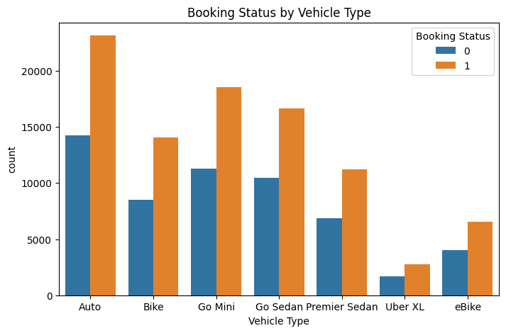

```python
#BookingStatus by Vehicle Type
plt.figure(figsize=(8,5))
sns.countplot(x="Vehicle Type", hue="Booking Status", data=df)
plt.title("Booking Status by Vehicle Type")
plt.show()
```

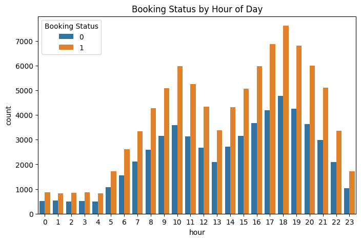

```python
#BookingStatus by Hour of Day
df["hour"] = df["Time"].dt.hour
plt.figure(figsize=(8,5))
sns.countplot(x="hour", hue="Booking Status", data=df)
plt.title("Booking Status by Hour of Day")
plt.show()
```

Booking activity increases sharply after 6 AM, peaks during morning commute 8–10 AM, and again during evening rush hours 5–8 PM. Failures rise in parallel with completions, showing that high demand periods lead to more unsuccessful bookings. Midday 11 AM–3 PM sees fewer rides overall but a steadier success rate. The pattern highlights how supply–demand mismatches during peak hours contribute to booking failures, a key operational insight for ride allocation.

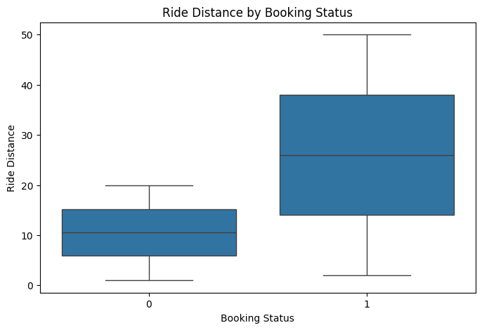

```python
plt.figure(figsize=(8,5))
sns.boxplot(x="Booking Status", y="Ride Distance", data=df)
plt.title("Ride Distance by Booking Status")
plt.show()
```

The boxplot shows a clear difference in ride distance between successful and failed bookings. Completed rides (1) generally span a wider range, with many medium-to-long trips (up to ~50 km), while failed bookings (0) are concentrated at shorter distances, mostly under 20 km. This suggests that customers attempting short trips may cancel more often, or drivers may deprioritize them due to lower fares. Longer trips, while less frequent, appear more likely to be completed. Overall, ride distance emerges as an informative feature for predicting booking status.

**PREDICTION**

```python
from sklearn.model_selection import train_test_split

# Target
y = df["Booking Status"]

# Features (start small & clean)
X = df[[
    "Vehicle Type",
    "Avg VTAT",
    "Avg CTAT",
    "Ride Distance",
    "hour"
]]

from sklearn.model_selection import train_test_split

X_train, X_test, y_train, y_test = train_test_split(
    X, y, test_size=0.2, stratify=y, random_state=1
)
```

```python
from sklearn.model_selection import train_test_split
from sklearn.compose import ColumnTransformer
from sklearn.preprocessing import OneHotEncoder, StandardScaler
from sklearn.pipeline import Pipeline
from sklearn.tree import DecisionTreeClassifier
from sklearn.ensemble import RandomForestClassifier
from xgboost import XGBClassifier
from sklearn.metrics import accuracy_score

#ColumnTransformer
preprocessor = ColumnTransformer(
    transformers=[
        ("cat", OneHotEncoder(handle_unknown="ignore"), ["Vehicle Type"]),
        ("num", StandardScaler(), ["Avg VTAT", "Avg CTAT"])
    ]
)

#Pipeline
pipelines = [
    ("Decision Tree", Pipeline([
        ("prep", preprocessor),
        ("clf", DecisionTreeClassifier(max_depth=5, random_state=1))
    ])),
    ("Random Forest", Pipeline([
        ("prep", preprocessor),
        ("clf", RandomForestClassifier(n_estimators=200, random_state=1, n_jobs=-1))
    ])),
    ("XGBoost", Pipeline([
        ("prep", preprocessor),
        ("clf", XGBClassifier(
            n_estimators=300, learning_rate=0.1, max_depth=6,
            subsample=0.8, colsample_bytree=0.8, random_state=1,
            eval_metric="logloss", n_jobs=-1
        ))
    ])),
]

#Train & evaluate
for name, pipe in pipelines:
    pipe.fit(X_train, y_train)
    y_pred = pipe.predict(X_test)
    acc = accuracy_score(y_test, y_pred)
    print(f"{name} Accuracy: {acc:.4f}")
```

```
Decision Tree Accuracy: 0.9529
Random Forest Accuracy: 0.9346
XGBoost Accuracy: 0.9527
```

**OPTIMIZATION**

```python
from sklearn.model_selection import GridSearchCV

# Decision Tree
param_dt = {
    "clf__max_depth": [5, 10],
    "clf__min_samples_split": [2, 5]
}

# Random Forest
param_rf = {
    "clf__n_estimators": [100, 200],
    "clf__max_depth": [10, None],
    "clf__min_samples_split": [2, 5]
}

# XGBoost
param_xgb = {
    "clf__n_estimators": [200, 400],
    "clf__max_depth": [4, 6],
    "clf__learning_rate": [0.05, 0.1],
    "clf__subsample": [0.8, 1.0]
}
```

```python
grid_rf = GridSearchCV(
    estimator=pipelines[1][1],
    param_grid=param_rf,
    cv=3,
    scoring="accuracy",
    n_jobs=-1,
    verbose=2
)

grid_rf.fit(X_train, y_train)

print("Best RF params:", grid_rf.best_params_)
print("Best RF score (CV):", grid_rf.best_score_)
```

```
Fitting 3 folds for each of 8 candidates, totalling 24 fits
Best RF params: {'clf__max_depth': 10, 'clf__min_samples_split': 5, 'clf__n_estimators': 100}
Best RF score (CV): 0.9531499999999999
```

**EVALUATION**

```python
from sklearn.model_selection import cross_val_score

# Run 5-fold cross-validation for each pipeline
for name, pipe in pipelines:
    scores = cross_val_score(pipe, X, y, cv=5, scoring="accuracy", n_jobs=-1)
    print(f"{name}: mean={scores.mean():.4f}, std={scores.std():.4f}")
```

```
Decision Tree: mean=0.9531, std=0.0010
```

```
Random Forest: mean=0.9370, std=0.0006
```

```
XGBoost: mean=0.9530, std=0.0010
```

```python
from sklearn.metrics import confusion_matrix, classification_report

# Loop through the trained pipelines and print confusion matrix and classification report
for name, pipe in pipelines:
    y_pred = pipe.predict(X_test)

    print(f"\n{name} - Confusion Matrix:")
    print(confusion_matrix(y_test, y_pred))

    print(f"\n{name} - Classification Report:")
    print(classification_report(y_test, y_pred, target_names=["Not Booked", "Booked"]))
```

```
Decision Tree - Confusion Matrix:
[[10046  1354]
 [   59 18541]]

Decision Tree - Classification Report:
              precision    recall  f1-score   support

  Not Booked       0.99      0.88      0.93     11400
      Booked       0.93      1.00      0.96     18600

    accuracy                           0.95     30000
   macro avg       0.96      0.94      0.95     30000
weighted avg       0.96      0.95      0.95     30000


Random Forest - Confusion Matrix:
[[10207  1193]
 [  768 17832]]

Random Forest - Classification Report:
              precision    recall  f1-score   support

  Not Booked       0.93      0.90      0.91     11400
      Booked       0.94      0.96      0.95     18600

    accuracy                           0.93     30000
   macro avg       0.93      0.93      0.93     30000
weighted avg       0.93      0.93      0.93     30000


XGBoost - Confusion Matrix:
[[10049  1351]
 [   68 18532]]

XGBoost - Classification Report:
              precision    recall  f1-score   support

  Not Booked       0.99      0.88      0.93     11400
      Booked       0.93      1.00      0.96     18600

    accuracy                           0.95     30000
   macro avg       0.96      0.94      0.95     30000
weighted avg       0.96      0.95      0.95     30000
```

The evaluation of the models on the test set shows that both Decision Tree and XGBoost achieved the highest accuracy (95%) with near-perfect recall for bookings, meaning they almost never miss customers who actually book. However, this comes with slightly lower precision, as they occasionally predict a booking that does not occur. The Random Forest model performed slightly worse overall (93% accuracy) but offered a more balanced trade-off between precision and recall. This means that prioritizing recall is more valuable since missing a true booking is costlier than predicting one that does not occur, making XGBoost or Decision Tree the preferred models.

**VISUALIZATION**

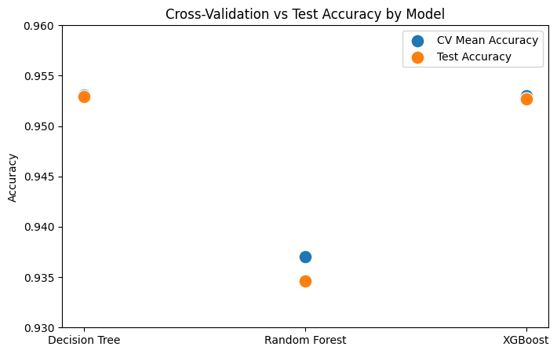

```python
import seaborn as sns
import matplotlib.pyplot as plt

models = ["Decision Tree", "Random Forest", "XGBoost"]
cv_means = [0.9531, 0.9370, 0.9530]
test_accs = [0.9529, 0.9346, 0.9527]

plt.figure(figsize=(8,5))

# CV points
sns.scatterplot(x=models, y=cv_means, s=150, label="CV Mean Accuracy")

# Test points
sns.scatterplot(x=models, y=test_accs, s=150, label="Test Accuracy")

plt.title("Cross-Validation vs Test Accuracy by Model")
plt.ylim(0.93, 0.96)
plt.ylabel("Accuracy")
plt.show()
```

The scatterplot shows that Decision Tree and XGBoost achieved nearly identical performance, with accuracies around 95.3% on both cross-validation and the test set. Random Forest performed slightly lower, at around 93.5%, but still showed stable results. The close alignment between cross-validation and test accuracies across all models suggests strong generalization without overfitting. Overall, XGBoost is the most reliable choice due to its robustness, while the Decision Tree offers similar accuracy with greater simplicity.

**REPORT**

A 95% accuracy means the model mostly correctly predicts the booking outcome (booked vs. not booked) for 95 out of 100 customers.

This level of accuracy suggests the model has learned strong patterns from the data and can be trusted for operational use, such as targeting customers at risk of not booking.

However, in practice, accuracy alone isn’t enough, you’d also want to check precision, recall, and confusion matrix to understand whether the model is better at catching bookers or non-bookers.

```python
from IPython.core.display import display, HTML

display(HTML('''
<style>
  pre {
    white-space: pre-wrap !important;  /* Wrap text */
    word-break: break-word !important; /* Prevent long words from overflowing */
  }
  .output_result {
    max-height: none !important; /* Remove scroll */
  }
  .output_area {
    overflow-y: visible !important; /* Prevent vertical scrolling */
  }
</style>
'''))
```

```python
# @markdown Run this cell to download this notebook as a webpage, `_NOTEBOOK.html`.

import google, json, nbformat

# Get the current notebook and write it to _NOTEBOOK.ipynb
raw_notebook = google.colab._message.blocking_request("get_ipynb",
                                                      timeout_sec=30)["ipynb"]
with open("_NOTEBOOK.ipynb", "w", encoding="utf-8") as ipynb_file:
  ipynb_file.write(json.dumps(raw_notebook))

# Use nbconvert to convert .ipynb to .html.
!jupyter nbconvert --to html --log-level WARN _NOTEBOOK.ipynb

# Download the .html file.
google.colab.files.download("_NOTEBOOK.html")
```